# Week 10, Day 1

```r
library(tidyverse)
library(broom)
library(ggfortify)
```

# MVP

## 1.

Load the data into a dataframe project

```r
project_management <- read_csv("data/project_management.csv")
```

## 2.

Plot the data, taking estimated_length as the independent variable and actual_length as the dependent variable.

Independent Variable / Predictor / X / estimated_length Dependent Variable / Response / Y / actual_length

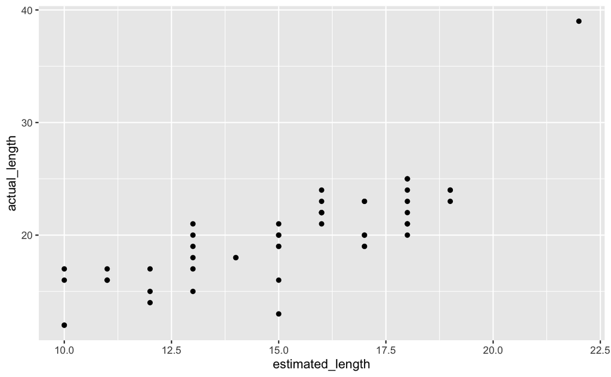

```r
project_management %>%
  ggplot() +
  geom_point(aes(x = estimated_length, y = actual_length))
```

```r
NA
```

## 3.

Calculate the correlation coefficient of estimated_length and actual_length and interpret the value you obtain.

```r
project_management %>%
  summarise(correlation_coefficient = cor(estimated_length, actual_length))
```

| correlation_coefficient |
| --- |
| 0.8046597 |

The correlation coefficient of estimated_length and actual_length is returned as 0.8046597. This suggests that their is a very strong correlation between estimated_length and actual_length.

## 4.

Perform a simple linear regression using actual_length as the dependent variable, and estimated_length as the independent variable. Save the model object to a variable.

```r
model <- lm(formula = actual_length ~ estimated_length,
             data = project_management)

model
```

```
Call:
lm(formula = actual_length ~ estimated_length, data = project_management)

Coefficients:
     (Intercept)  estimated_length
           1.416             1.223
```

## 5.

Interpret the regression coefficient of estimated_length (i.e. slope, gradient) you obtain from the model. How do you interpret the r2 value reported by the model?

The coefficient of estimated_length is returned as 1.223. This means that for every unit increase of estimated_length the actual_length is expected to increase by 1.223 units.

The r-squared value returned is 0.6474772. We can therefor say that our simple linear model says that 65% of the variation in actual_duration can be explained by the estimated_duration.

```r
glance(model)
```

| r.squared | adj.r.squared | sigma | statistic | p.value | df | logLik | AIC | BIC | deviance | df.residual | nobs |
| --- | --- | --- | --- | --- | --- | --- | --- | --- | --- | --- | --- |
| 0.6474772 | 0.640133 | 2.606163 | 88.16142 | 1.911284e-12 | 1 | -117.8203 | 241.6407 | 247.3767 | 326.0201 | 48 | 50 |

## 6.

Is the relationship statistically significant? Remember, to assess this you need to check the p -value of the regression coefficient (or slope/gradient). But you should first check the regression diagnostic plots to see if the p-value will be reliable (don’t worry about any outlier points you see in the diagnostic plots, we’ll return to them in the extension).

- Residuals vs. Fitted There doesn’t appear to be any strong pattern here, which supports the reliability of the p-value.
- Normal QQ There distribution of the residuals appears to be mostly normal, with the exception of a couple of outliers, supporting the reliability of the p-value.
- Scale Location The spread of residuals appears to be fairly consistent across all fitted values, supporting reliability of the p-value.

The p-value returned is very low, suggesting that the relationship is statistically significant.

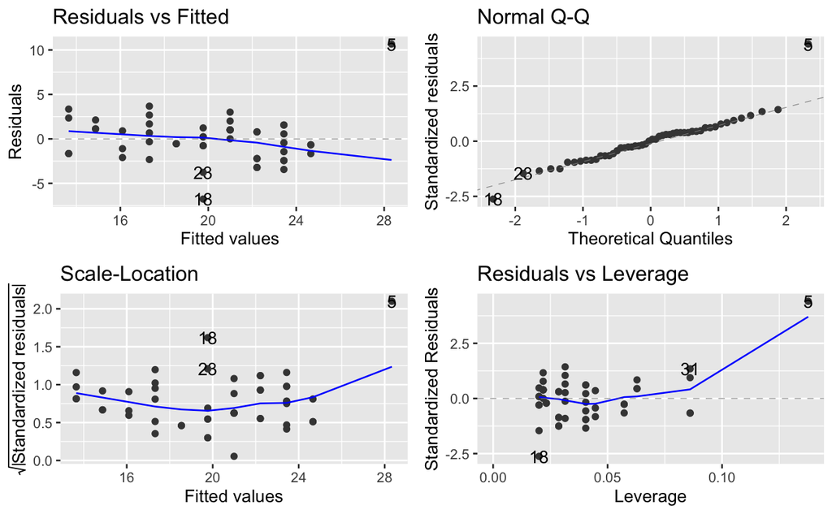

```r
autoplot(model)
```